# Dimension_reduction

Xinying Fang

2/27/2022

```r
library(factoextra)
library(purrr)
library(NMF)
```

## load data

```r
gene <- read.delim("/Users/rrrrrita/Documents/GitHub/PHS597DeepLearning/gene_expression_sample/GEUVADIS_normalized_expression_chr20")
geneexp <- gene[,c(1,5:ncol(gene))]
genotype <- read.delim("/Users/rrrrrita/Documents/GitHub/PHS597DeepLearning/gene_expression_sample/GEUVADIS_chr20_processed.traw")
```

```r
head(gene)
```

```
##           gene_id chromosome    start      end    HG00096   HG00097   HG00099
## 1 ENSG00000000419         20 49551404 49575092 28.2998668 23.463226 17.729644
## 2 ENSG00000020256         20 50668202 50820847 10.4068864 10.554142  4.431538
## 3 ENSG00000022277         20 55043647 55093943 48.9170004 48.592840 31.769222
## 4 ENSG00000025293         20 34359896 34538303 13.6876109 17.046651  7.648451
## 5 ENSG00000025772         20 43570771 43589127 17.1638428 15.373224  9.125615
## 6 ENSG00000026036         20 62290653 62330037  0.9472564  1.786716  1.160909
##     HG00100   HG00101   HG00102   HG00103   HG00105   HG00106   HG00108
## 1 25.844493 27.568971 25.976945 28.199575 27.489008 27.798654 23.280516
## 2  8.562854 11.275014  7.649553 15.890562 10.877197  9.587577  8.605050
## 3 55.296140 53.436246 43.149509 71.758371 45.588445 74.700172 44.044606
## 4  9.999433 12.047031 10.041513 14.585292  9.822095 12.367401 11.522112
## 5 19.737871 17.857086 18.208972 21.491493 16.915226 20.837922 15.814537
## 6  1.680259  1.306978  1.187033  1.535652  1.256980  1.100991  1.495228
##     HG00109   HG00110   HG00111   HG00112   HG00114   HG00115   HG00116
```

[output cut: 349 more lines]

```r
head(genotype)
```

```
##   CHR               SNP X.C.M   POS COUNTED ALT HG00096_HG00096 HG00097_HG00097
## 1  20  20_61098_C_T_b37     0 61098       C   T               2               2
## 2  20 20_61138_C_CT_b37     0 61138       C  CT               2               1
## 3  20  20_61795_G_T_b37     0 61795       G   T               1               2
## 4  20  20_62731_C_A_b37     0 62731       C   A               1               2
## 5  20  20_63244_A_C_b37     0 63244       A   C               2               2
## 6  20  20_63799_C_T_b37     0 63799       C   T               1               2
##   HG00099_HG00099 HG00100_HG00100 HG00101_HG00101 HG00102_HG00102
## 1               2               2               1               2
## 2               2               2               1               2
## 3               2               2               1               2
## 4               2               2               2               2
## 5               2               2               1               2
## 6               2               2               1               2
##   HG00103_HG00103 HG00105_HG00105 HG00106_HG00106 HG00108_HG00108
```

[output cut: 615 more lines]

## Vector quantization (VQ)

VQ is one type of k means. First I determined the optimal k based on total within-cluster sum of square:

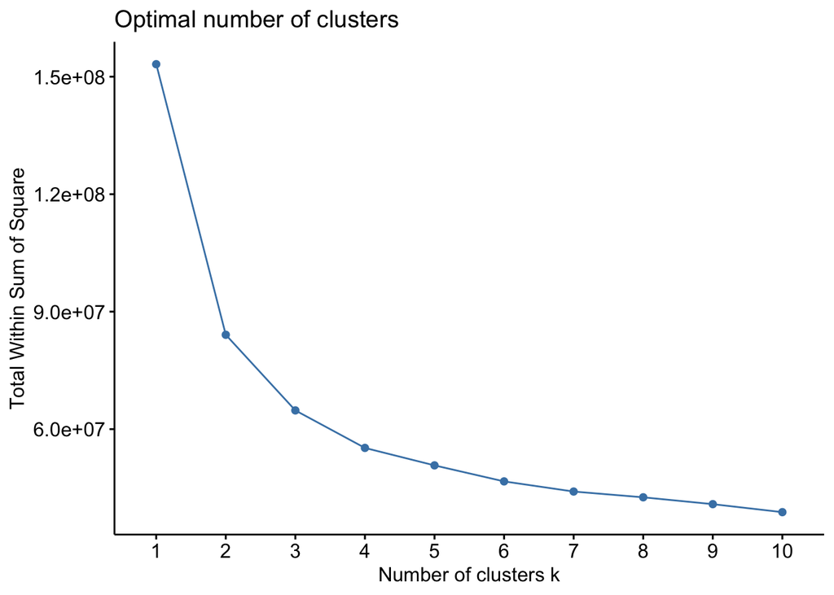

```r
wss <- function(k) {
  kmeans(t(geneexp[,-1]), k, nstart = 10 )$tot.withinss
}

fviz_nbclust(t(geneexp[-1]), kmeans, method = "wss")
```

The elbow point happens at k=2 or 3. Here I chose k=3:

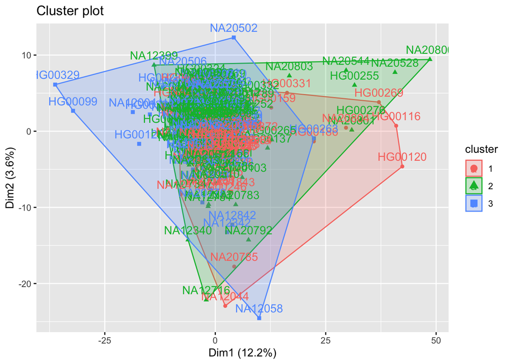

```r
kres <- kmeans(t(geneexp[-1]), 3, nstart = 1)
fviz_cluster(kres, data = t(geneexp[-1]))
```

The cluster plot tells that it is hard to discern these samples based on gene expression.

I used the centroid values of each cluster to represent samples within each cluster:

```r
y_vq <- kres$centers[kres$cluster,]
rownames(y_vq) <- colnames(geneexp[,-1])
```

## PCA

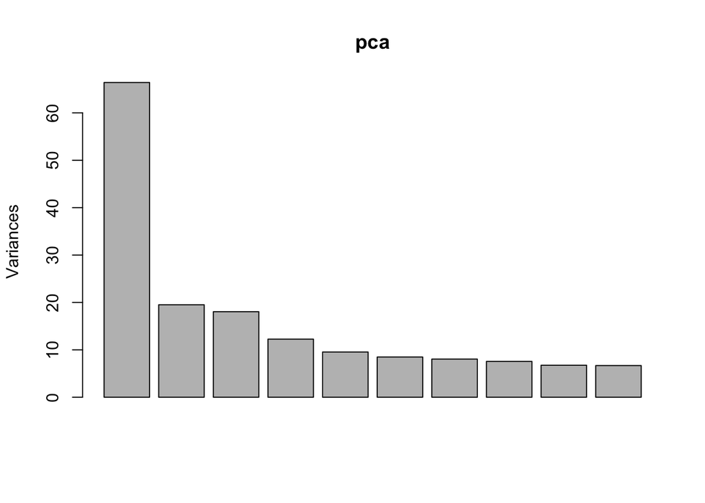

```r
pca <- prcomp(t(geneexp[-1]), center=TRUE, scale = TRUE)
plot(pca, npcs=10)
```

(It is also reasonable to choose first 3 PCs)

```r
pca <- prcomp(t(geneexp[-1]), center=TRUE, scale = FALSE)
pc <- pca$x
rotation <- pca$rotation

npc <- 10
colm <- colMeans(t(geneexp[,-1]))

y_pca <- pc[,1:npc] %*% t(rotation[,1:npc]) + colm
```

## NMF

First, run several experiments to select the optimal rank:

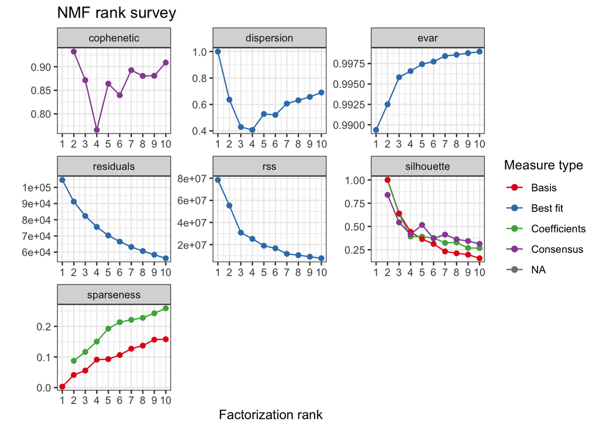

```r
geneexp_nmf <- t(geneexp[-1])

# transfer into nonnegative data
geneexp_nmf <- nneg(geneexp_nmf)
estim.r <- nmf(geneexp_nmf, 1:10, nrun=20, seed=123456)
plot(estim.r)
estim.r
```

For optimal rank, (Frigyesi 2008) considered the smallest value at which the decrease in the RSS is lower than the decrease of the *RSS* obtained from random data. From the above RSS plot, the decrease from 3 to 4 is lower than the decrease from 1 to 2 and 2 to 3. Therefore, I chose rank = 4.

```r
geneexp_nmf <- t(geneexp[-1])
# transfer into nonnegative data
geneexp_nmf <- nneg(geneexp_nmf)

nmffit <- nmf(geneexp_nmf, rank=4, "brunet", seed=123456) # higher rank -> better results
w <- nmffit@fit@W
h <- nmffit@fit@H
y_nmf <- w %*% h
```

## Results comparison

### eQTL analysis

To conduct the eQTL analysis, I filtered the data within 500000 downstream and upstream of gene start and end sites. I regressed each gene expression (SNP) on each genotype. The Benjamini-Hochberg method was applied

```r
resdf <- c()
eqtl <- function(gexp){

  for ( i in 1:nrow(gene)){
    gtype <- subset(genotype, POS >= (gene$start[i] - 500000) & POS <= (gene$end[i] + 500000))
    gtype <- gtype[,-(1:6)]
    y <- gexp[,i]

    resdf1 <- c()
    for ( j in 1:nrow(gtype)){
      x <- t(gtype[j,])
      lmfit <- lm(y ~ x)

      out <- data.frame(gene=gene$gene_id[i],
                        genotype = genotype$SNP[j],
                        pval = summary(lmfit)$coefficients[2,4])
      resdf1 <- rbind(resdf1, out)
    }
    resdf1$pval <- p.adjust(resdf1$pval, method = "BH")
    resdf <- rbind(resdf, resdf1)
  }

  return(resdf)
}
```

```r
# Read saved results
vq <- readRDS("vq_dopar.rds")
pca <- readRDS("pca_dopar.rds")
nmf <- readRDS("nmf_dopar.rds")
uncomp <- readRDS("uncomp_dopar.rds")
```

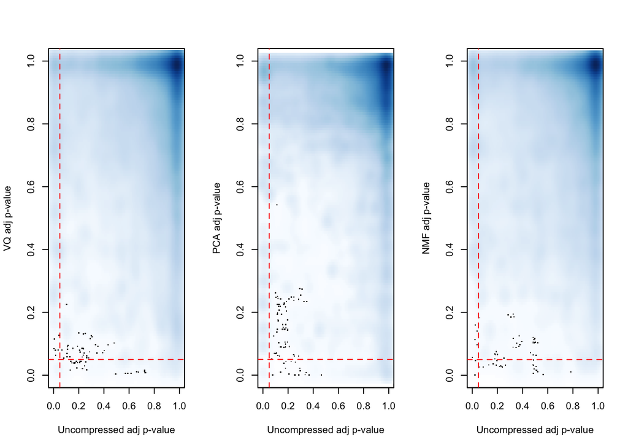

```r
par(mfrow=c(1,3))
smoothScatter(x=uncomp$pval, y=vq$pval,
              xlab = "Uncompressed adj p-value", ylab = "VQ adj p-value")
abline(v = 0.05, h=0.05, lty = 2, col = "red")
smoothScatter(x=uncomp$pval, y=pca$pval,
              xlab = "Uncompressed adj p-value", ylab = "PCA adj p-value")
abline(v = 0.05, h=0.05, lty = 2, col = "red")
smoothScatter(x=uncomp$pval, y=nmf$pval,
              xlab = "Uncompressed adj p-value", ylab = "NMF adj p-value")
abline(v = 0.05, h=0.05, lty = 2, col = "red")
```

It’s not easy to see a linear relationship between adjusted p-values for uncomparessed dataset and compressed dataset with three dimension reduction methods. Then we further evaluate the relationship with confusion matrices:

### Confusion matrix

```r
binary.pval <- function(x){
  y <- ifelse(x<0.05, 1, 0)
  y <- factor(y, levels = c(0,1))
  return(y)
}
vq_cm <- caret::confusionMatrix(data = binary.pval(vq$pval),
                       reference = binary.pval(uncomp$pval))
pca_cm <- caret::confusionMatrix(data = binary.pval(pca$pval),
                       reference = binary.pval(uncomp$pval))

nmf_cm <- caret::confusionMatrix(data = binary.pval(nmf$pval),
                       reference = binary.pval(uncomp$pval))
```

```r
byClass <- rbind(VQ =round(vq_cm$byClass, 3),
                 PCA=round(pca_cm$byClass, 3),
                 NMF = round(nmf_cm$byClass, 3))

overall <- rbind(VQ =round(vq_cm$overall, 3),
                 PCA=round(pca_cm$overall, 3),
                 NMF = round(nmf_cm$overall, 3))
byClass
```

```
##     Sensitivity Specificity Pos Pred Value Neg Pred Value Precision Recall
## VQ        0.998       0.006          0.979          0.074     0.979  0.998
## PCA       0.998       0.005          0.979          0.044     0.979  0.998
## NMF       0.999       0.000          0.979          0.001     0.979  0.999
##        F1 Prevalence Detection Rate Detection Prevalence Balanced Accuracy
## VQ  0.989      0.979          0.978                0.998             0.502
## PCA 0.988      0.979          0.977                0.998             0.501
## NMF 0.989      0.979          0.978                0.999             0.499
```

```r
overall
```

```
##     Accuracy  Kappa AccuracyLower AccuracyUpper AccuracyNull AccuracyPValue
## VQ     0.978  0.008         0.978         0.978        0.979              1
## PCA    0.977  0.005         0.977         0.977        0.979              1
## NMF    0.978 -0.002         0.978         0.978        0.979              1
##     McnemarPValue
## VQ              0
## PCA             0
## NMF             0
```

All three methods have high sensitivity but low specificity. NMF has the lowest negative predictive value among the three. For other measurements, these three methods are pretty much the same.